# Developing an AI application of Image Classifier

In this project, an image classifier will be trained to recognize different species of flowers. [This dataset](http://www.robots.ox.ac.uk/~vgg/data/flowers/102/index.html) of 102 flower categories will be used in this project.

The project is broken down into multiple steps:

- Load and preprocess the image dataset
- Train the image classifier on your dataset
- Use the trained classifier to predict image content

After fininishing this part you will have an application that can be trained on any set of labeled images.

### At first, loading packages at front which wiil be needed for the whole project

```python
# Imports here
import torch
from torchvision import datasets, transforms
import torchvision.models as models

import torch.nn as nn
import torch.nn.functional as F
from torch import optim

import pandas as pd
from collections import OrderedDict
import json


from PIL import Image
import numpy as np
import matplotlib.pyplot as plt
```

## Load the data

The validation and testing sets are used to measure the model's performance on data it hasn't seen yet. For this scaling or rotation transformations won't be needed, but need to resize then crop the images to the appropriate size.

The pre-trained networks were trained on the ImageNet dataset where each color channel was normalized separately. For all three sets you'll need to normalize the means and standard deviations of the images to what the network expects. For the means, it's `[0.485, 0.456, 0.406]` and for the standard deviations `[0.229, 0.224, 0.225]`, calculated from the ImageNet images. These values will shift each color channel to be centered at 0 and range from -1 to 1.

```python
data_dir = 'flowers'
train_dir = data_dir + '/train'
valid_dir = data_dir + '/valid'
test_dir = data_dir + '/test'
```

```python
# Define transforms for the training, validation, and testing sets
train_data_transforms = transforms.Compose([
                                      transforms.Resize(256),
                                      transforms.CenterCrop(224),
                                      transforms.RandomRotation(30),
                                      transforms.RandomHorizontalFlip(),
                                      transforms.ToTensor(),
                                      transforms.Normalize([0.485,0.456,0.406],
                                                           [0.229,0.224,0.225])])

valid_test_data_transforms = transforms.Compose([
                                                 transforms.Resize(256),
                                                 transforms.CenterCrop(224),
                                                 transforms.ToTensor(),
                                                 transforms.Normalize([0.485,0.456,0.406],
                                                                      [0.229,0.224,0.225])])

# Load the datasets with ImageFolder
image_datasets_train = datasets.ImageFolder(train_dir, transform = train_data_transforms)
image_datasets_validation = datasets.ImageFolder(valid_dir, transform = valid_test_data_transforms)
image_datasets_test = datasets.ImageFolder(test_dir, transform = valid_test_data_transforms)



# Using the image datasets and the trainforms, define the dataloaders
train_dataloaders = torch.utils.data.DataLoader(image_datasets_train, batch_size= 64, shuffle= True)
valid_dataloaders = torch.utils.data.DataLoader(image_datasets_validation, batch_size= 32, shuffle= True)
test_dataloaders = torch.utils.data.DataLoader(image_datasets_test, batch_size= 32, shuffle= True)
```

### Label mapping

Mapping category label to category name. You can find this in the file `cat_to_name.json`. It's a JSON object which you can read in with the [`json` module](https://docs.python.org/2/library/json.html). This will give you a dictionary mapping the integer encoded categories to the actual names of the flowers.

```python
with open('cat_to_name.json', 'r') as f:
    cat_to_name = json.load(f)
```

# Building and training the classifier

Now that the data is ready, it's time to build and train the classifier. One of the pretrained models from `torchvision.models` to get the image features. Build and train a new feed-forward classifier using those features.

- Load a [pre-trained network](http://pytorch.org/docs/master/torchvision/models.html)
- Define a new, untrained feed-forward network as a classifier, using ReLU activations and dropout
- Train the classifier layers using backpropagation using the pre-trained network to get the features
- Track the loss and accuracy on the validation set to determine the best hyperparameters

```python
def network_build(pre_train_model, input_size, hidden_sizes, output_size, drop_p):
    """ Load pre-trained network and construct new untrained feed-forward network as the classifer.
    INPUT: pre_train_model, the selected pre-trained network from TorchVision.
           input_size, int, the input size of the untrained feed-forward classifier.
           hidden_sizes: list of int to represnet sizes of the network's hidden layer.
           output_size, int,  the output size of the untrained feed-forward classifier

    OUTPUT: pre-trained model with new feed-forward classifer.
    """

    #initialize pre-tarined model
    model = pre_train_model

    ## to be filled
    for para in model.parameters():
        para.requires_grad = False

    # intialize an empty newwork layer list for contraining new classifier
    network_layers = []

    # first layer
    network_layers.append(('fc1', nn.Linear(input_size, hidden_sizes[0])))
    network_layers.append(('ReLu1', nn.ReLU()))
    network_layers.append(('Dropout1', nn.Dropout(drop_p)))

    # hidden layers
    for n in range(len(hidden_sizes)):

        if n == (len(hidden_sizes) - 1):

            network_layers.append(('fc_out', nn.Linear(hidden_sizes[n], output_size)))
            network_layers.append(('out_log', nn.LogSoftmax(dim = 1)))

        else:
            network_layers.append(('fc' + str(n+2), nn.Linear(hidden_sizes[n], hidden_sizes[n+1])))
            network_layers.append(('ReLu' + str(n+2), nn.ReLU()))
            network_layers.append(('Dropout' + str(n+2) , nn.Dropout(drop_p)))

    # construct feed-forward network with layer list
    img_network = nn.Sequential(OrderedDict(network_layers))
    # set as pre-trained network's classifer
    model.classifier = img_network

    return model
```

```python
def validation_test(trained_model, dataloaders_check, criterion, device):
    """ Use trained image model to do prediction on validation dataset
    INPUT: trained_model, the pretrained model with new classifier layers
           dataloaders_check, validation/test dataloaders
           criterion: used to calculate loss
           device: 'cpu'/'cuda'
    OUTPUT: validation/testing loss & accuracy
    """
    # set as evaluation mode
    trained_model.eval()

    # initialize metrics
    val_test_loss = 0
    total_img = 0
    val_test_correct_num = 0

    for val_test_images, val_test_labels in iter(dataloaders_check):

        val_test_images, val_test_labels = val_test_images.to(device), val_test_labels.to(device)

        # forward output
        val_test_output = trained_model.forward(val_test_images)
        # transform logged result to original
        val_test_exp = torch.exp(val_test_output)
        # record val_testidation set los
        val_test_loss += criterion(val_test_output, val_test_labels).item()

        # record pred correction number
        total_img += len(val_test_images)
        val_test_correct_num += (val_test_exp.max(dim = 1)[1] == val_test_labels.data).type(torch.FloatTensor).sum()

    val_test_accuracy = val_test_correct_num/total_img

    return val_test_loss, val_test_accuracy
```

```python
def image_training_validation(epochs,model,dataloader_train, dataloader_valid, criterion, img_lr, device):
    """ Train image NN model and do validation during training process
    INPUT: epochs, int, number of training rounds
           model, pre-trained model
           dataloader_train, training dataset
           dataloader_valid, validation dataset
           criterion: used for calculating loss
           img_lr: learning rate
           device: 'cpu'/'cuda'
    OUTPUT: trained model, print out training loss, validation loss and validation accuracy
    """
    # set optimizer
    img_optimizer = optim.Adam(model.classifier.parameters(), lr = img_lr)

    # defining initial metrics
    training_loss = 0
    training_loss = 0
    print_fold = 40

    steps = 0

    model.to(device)

    for e in range(epochs):

        for images, labels in iter(dataloader_train):

            # set model as traning mode
            model.train()

            images, labels = images.to(device), labels.to(device)

            steps += 1

            img_optimizer.zero_grad()
            # make forward feed
            output = model.forward(images)

            # take loss
            loss = criterion(output, labels)

            # backwards
            loss.backward()

            # aggregate training loss
            training_loss += loss.item()

            # update weights
            img_optimizer.step()


            # print training loss and test on validataion at every print_fold
            if steps % print_fold == 0:

                # output training loss
                print('In No. {} epoch'.format(e+1))
                print('training loss: {:.4f}'.format(training_loss))

                # test on validation set
                # set model as validation mode
                with torch.no_grad():
                    val_loss, val_accur = validation_test(model, dataloader_valid, criterion, device)

                # print validation loss
                print('validation loss: {:.4f}'.format(val_loss))

                # print validation accuracy
                print('validation accuracy: {:.2f}'.format(val_accur))

                # reset training loss
                training_loss = 0

                # rest to train mode
                model.train()

    return model
```

```python
# set new feed-ward classifier
flwer_model = network_build(models.vgg16_bn(pretrained= True), 25088, [8000, 3000], 121, 0.1)
flwer_model.classifier
```

```
Sequential(
  (fc1): Linear(in_features=25088, out_features=8000, bias=True)
  (ReLu1): ReLU()
  (Dropout1): Dropout(p=0.1)
  (fc2): Linear(in_features=8000, out_features=3000, bias=True)
  (ReLu2): ReLU()
  (Dropout2): Dropout(p=0.1)
  (fc_out): Linear(in_features=3000, out_features=121, bias=True)
  (out_log): LogSoftmax()
)
```

```python
# Train the new constructed network
flwer_model = image_training_validation(6,flwer_model,train_dataloaders,valid_dataloaders,nn.NLLLoss(),0.001,'cuda')
```

```
In No. 1 epoch
training loss: 154.1115
validation loss: 61.3442
validation accuracy: 0.43
In No. 1 epoch
training loss: 73.0078
validation loss: 33.3785
validation accuracy: 0.65
In No. 2 epoch
training loss: 41.5157
validation loss: 25.4523
validation accuracy: 0.73
In No. 2 epoch
training loss: 28.8605
validation loss: 21.0635
validation accuracy: 0.77
In No. 2 epoch
training loss: 24.9231
validation loss: 18.4915
validation accuracy: 0.79
In No. 3 epoch
training loss: 18.1857
validation loss: 16.0798
validation accuracy: 0.84
In No. 3 epoch
training loss: 16.6824
validation loss: 17.1092
validation accuracy: 0.81
In No. 4 epoch
training loss: 15.1700
validation loss: 16.9861
validation accuracy: 0.82
In No. 4 epoch
training loss: 12.8252
validation loss: 16.1556
validation accuracy: 0.83
In No. 4 epoch
training loss: 12.0481
validation loss: 14.6163
validation accuracy: 0.85
In No. 5 epoch
training loss: 10.9395
validation loss: 14.2704
validation accuracy: 0.85
In No. 5 epoch
training loss: 9.3050
validation loss: 16.7670
validation accuracy: 0.84
In No. 6 epoch
training loss: 11.9372
validation loss: 13.0218
validation accuracy: 0.87
In No. 6 epoch
training loss: 7.1742
validation loss: 13.2853
validation accuracy: 0.88
In No. 6 epoch
training loss: 8.9715
validation loss: 15.9734
validation accuracy: 0.84
```

## Testing network

Test data will be used to test the trained model, images the network has never seen either in training or validation.

```python
# Do validation on the test set
with torch.no_grad():
    test_loss, test_accu = validation_test(flwer_model, test_dataloaders, nn.NLLLoss(), 'cuda')

test_accu
```

```
tensor(0.8547)
```

## Save the checkpoint

Save the model so it can be loaded later for making predictions.To include any information needed in the checkpoint.

```python
# Save the checkpoint
flwer_model.class_to_idx = image_datasets_train.class_to_idx

n_line = len(flwer_model.classifier)
hiddensizes = []

for n in range(n_line):
    # check if is the 'Linear' object
    if n % 3 == 0:
        # check if the first
        if n == 0:
            # get the input size
            inputsize = flwer_model.classifier[n].in_features
        # check if the last for getting output size
        elif n == n_line - 2:
            # get the last hidden layer's size
            hiddensizes.append(flwer_model.classifier[n].in_features)
            # get the output size
            outputsize = flwer_model.classifier[n].out_features

        # get the rest hidden sizes info
        else:
            hiddensizes.append(flwer_model.classifier[n].in_features)

    # get the drop out probability
    if n == 2:
        dropprop = flwer_model.classifier[n].p


# Save Model
flwer_checkpoint = {'pre_trained_model':models.vgg16_bn(pretrained= True),
                    'input_size': inputsize,
                    'hidden_sizes': hiddensizes,
                    'output_size': outputsize,
                    'drop_prop': dropprop,
                    'state_dict': flwer_model.state_dict(),
                    'class_to_idx':flwer_model.class_to_idx}
```

```python
# Save the model
torch.save(flwer_checkpoint,'VGG16_CN_flwer_checkpoint.pth')
```

## Loading the checkpoint

Write a function that can load a checkpoint and rebuild the model.

```python
# Function that loads a checkpoint and rebuilds the model
def load_flwer_model(flwer_file_path):
    check_point = torch.load(flwer_file_path)

    model = network_build(check_point['pre_trained_model'], check_point['input_size'], check_point['hidden_sizes']\
                          ,check_point['output_size'], check_point['drop_prop'])

    model.load_state_dict(check_point['state_dict'])
    model.class_to_idx = check_point['class_to_idx']

    return model
```

```python
# loads a checkpoint and rebuilds the model
flwer_load_model = load_flwer_model('VGG16_CN_flwer_checkpoint.pth')
```

# Inference for classification

Build a function to use a trained network for inference. An image will be passed into the network and predict the class of the flower in the image. A function called `predict` that takes an image and a model, then returns the top $K$ most likely classes along with the probabilities.

First process the input image such that it can be used in the network.

## Image Preprocessing

Use `PIL` to load the image ([documentation](https://pillow.readthedocs.io/en/latest/reference/Image.html)).

First, resize the images where the shortest side is 256 pixels, keeping the aspect ratio. Then to crop out the center 224x224 portion of the image.

Color channels of images are typically encoded as integers 0-255, but the model expected floats 0-1. The values need to be converted.

Network expects the images to be normalized in a specific way. For the means, it's `[0.485, 0.456, 0.406]` and for the standard deviations `[0.229, 0.224, 0.225]`. Subtract the means from each color channel, then divide by the standard deviation.

And finally, PyTorch expects the color channel to be the first dimension but it's the third dimension in the PIL image and Numpy array. Reorder dimensions using [`ndarray.transpose`](https://docs.scipy.org/doc/numpy-1.13.0/reference/generated/numpy.ndarray.transpose.html). The color channel needs to be first and retain the order of the other two dimensions.

```python
def process_image(image):
    ''' Scales, crops, and normalizes a PIL image for a PyTorch model,
        returns an Numpy array
    '''

    # TODO: Process a PIL image for use in a PyTorch model

    # resize
    w, h = image.size
    if w < h:
        w_r = 256
        h_r = int(w_r/w * h)
    else:
        h_r = 256
        w_r = int(h_r/h * w)

    image_resize = image.resize((w_r,h_r))


    # center crop
    left_w = (w_r - 224)/2
    right_w = (w_r + 224)/2
    top_h = (h_r - 224 )/2
    botm_h = (h_r + 224)/2

    image_crop = image_resize.crop((left_w,top_h,right_w,botm_h))

    # convert to 0-1
    np_image = np.array(image_crop)/ 255

    normal_image = (np_image - np.array([0.485, 0.456, 0.406]))/np.array([0.229, 0.224, 0.225])

    # re-order
    reorder_img = normal_image.transpose((2,0,1))

    return reorder_img
```

To check your work, the function below converts a PyTorch tensor and displays it in the notebook. If your `process_image` function works, running the output through this function should return the original image (except for the cropped out portions).

```python
def imshow(image, ax=None, title=None):
    if ax is None:
        fig, ax = plt.subplots()

    # PyTorch tensors assume the color channel is the first dimension
    # but matplotlib assumes is the third dimension
    image = image.transpose((1, 2, 0))

    # Undo preprocessing
    mean = np.array([0.485, 0.456, 0.406])
    std = np.array([0.229, 0.224, 0.225])
    image = std * image + mean

    # Image needs to be clipped between 0 and 1 or it looks like noise when displayed
    image = np.clip(image, 0, 1)

    ax.imshow(image)

    return ax
```

## Class Prediction

It's time to make predictions with the model. Here to predict the top $K$ probable classes. Calculate the class probabilities then find the $K$ largest values.

```python
def predict(image_path, model, topk=5):
    ''' Predict the class (or classes) of an image using a trained deep learning model.
        Return predicted probablities and index
    '''

    # Implement the code to predict the class from an image file
    model.eval()
    model.to('cpu')
    model.double()

    img = process_image(Image.open(image_path))

    with torch.no_grad():
        # forward output
        pred_ori = model.forward(torch.from_numpy(img).unsqueeze_(0))
        # transform logged result to original
        pred = torch.exp(pred_ori)

        prob, idx = pred.topk(topk)

    return prob.numpy()[0].tolist(), idx.numpy()[0].tolist()
```

```python
spc_prob, spc_idx = predict('flowers/test/1/image_06752.jpg', flwer_load_model, 5)
```

```python
spc_prob
```

```
[0.8907440921298848,
 0.034758738961378585,
 0.03186167662501379,
 0.006285463590525101,
 0.0038729565776644734]
```

```python
spc_idx
```

```
[0, 66, 87, 95, 42]
```

## Sanity Checking

Use a trained model for predictions, check to make sure it makes sense. To plot the probabilities for the top 5 classes along with the input image.

```python
def pred_top_name(image_path, model, topk):
    # prediction
    spc_prob, spc_idx = predict(image_path, model, topk)

    #
    spc_idx_class = []
    spc_idx_names = []

    for key, value_1 in model.class_to_idx.items():
        for value_2 in spc_idx:
            if value_1 == value_2:
                spc_idx_class.append(key)

    for cat in spc_idx_class:
        spc_idx_names.append(cat_to_name[cat])


    imshow(process_image(Image.open(image_path)))


    df = pd.DataFrame(list(zip(spc_idx_names,spc_prob)), columns= ['name','probabilty']).sort_values(['probabilty'], ascending = True)
    df.plot.barh()
    plt.yticks(range(len(df)), df['name'])
    plt.show()

    return
```

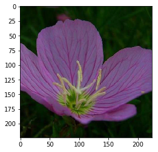

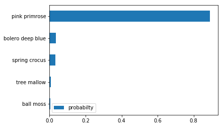

```python
pred_top_name('flowers/test/1/image_06752.jpg', flwer_load_model, 5)
```